# Методы экспоненциального сглаживания

Заходякин Г.В., postlogist@gmail.com

```r
options(digits = 3) # Количество значащих цифр при выводе
```

```r
library(tidyverse) # визуализация и трансформация данных
library(forecast) # анализ временных рядов и прогнозирование
library(fpp) # Примеры временных рядов
library(sophisthse) # Загрузка временных рядов из базы Sophist
```

# Введение

Методы экспоненциального сглаживания начиная с середины XX века широко применяются для анализа временных рядов и прогнозирования в технике и управлении. Применение методов экспоненциального сглаживания для прогнозирования включает два этапа: сначала на основе имеющихся данных получают оценки для закономерных компонентов ряда - *уровня*, *тренда* (скорости роста) и *сезонных коэффициентов*. Затем, комбинируя наиболее свежие оценки закономерных компонентов ряда, строится прогноз на будущее.

Оценки закономерных компонентов при получении новых данных корректируются с использованием ошибки прогноза на текущем шаге и **константы сглаживания**, которая задает долю от величины ошибки, которая будет использоваться для корректировки прогноза. На рисунке показана схема работы метода простого экспоненциального сглаживания.

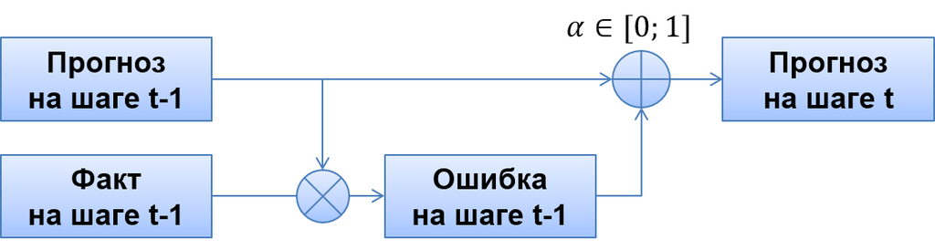

Схема метода простого экспоненциального сглаживания

Сглаженное значение на шаге $t$ определяется по формуле:

$$L_t = L_{t-1} + \alpha (y_t - L_{t-1}) = L_{t-1} + \alpha e_t$$

Своим названием методы обязаны тому, что при развертывании рекуррентной формулы, приведенной выше, прошлые наблюдения получают экспоненциально затухающие веса:

$$L_t = L_{t-1} + \alpha (y_t - L_{t-1}) = \alpha y_t + L_{t-1} (1 - \alpha) = \\
\alpha y_t + \alpha (1 - \alpha) y_{t-1} + (1 - \alpha)^2 L_{t-2} = \\
\alpha y_t + \alpha (1 - \alpha) y_{t-1} + \alpha (1 - \alpha)^2 y_{t-2} + (1 - \alpha)^3 L_{t-3}$$

Поскольку $\alpha < 1$, наиболее свежие наблюдения получают большие веса, чем более давние наблюдения.

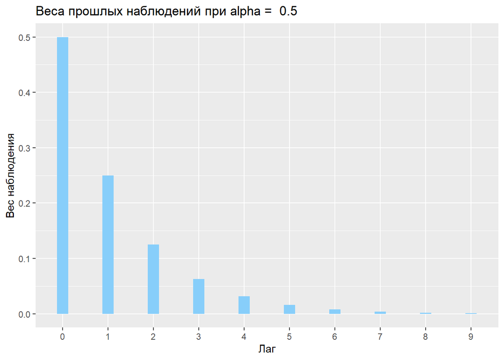

```r
# Значение константы сглаживания
a <- 0.5
# Коэффициенты
i <- 0:9
coefs <- a * (1 - a)^i
# Визуализация
ggplot(tibble(x = factor(i), y = coefs)) +
  geom_bar(aes(x, y), stat = 'identity', fill = 'lightskyblue', width = 0.25) +
  labs(title = paste('Веса прошлых наблюдений при alpha = ', a),
       x = 'Лаг', y = 'Вес наблюдения')
```

Методы экспоненциального сглаживания позволяют быстро получать прогнозы для широкого спектра временных рядов и способны адаптироваться к изменению закономерных компонентов ряда. Это сделало их одним из наиболее популярных и успешных подходов при разработке инструментов автоматизированного прогнозирования.

В этом блокноте будут рассмотрены классические методы экспоненциального сглаживания - простое экспоненциальное сглаживание, метод Хольта и метод Винтерса.

Материал составлен на основе [7 главы](https://www.otexts.org/fpp2/ch-expsmooth.html) книги: *Hyndman R, Athanasopoulos G. Forecasting Principles and Practice, 2nd Edition*.

# Простое экспоненциальное сглаживание

Метод **простого экспоненциального сглаживания** (*simple exponential smoothing, SES*) позволяет выделить лишь среднее значение временного ряда - **уровень** (*Level*). Для получения этого компонента используется формула:

$$L_t = y_t \cdot \alpha + L_{t-1} \cdot (1 - \alpha),$$

где $\alpha \in [0, 1]$ - константа сглаживания, которая определяет скорость реакции уровня ряда $L$ на изменения в наблюдаемых значениях $y$. Чем больше $\alpha$, тем быстрее уровень реагирует на изменения и тем меньше сглаживание.

При $\alpha = 0$ обновление уровня не происходит при изменении $y$, сохраняется начальное значение уровня - $L_1$.

Первоначальное значение уровня - $L_1$ необходимо задать (**инициализировать**).

При прогнозировании в методе простого экспоненциального сглаживания применяется наивный подход, предполагающий, что все последующие наблюдения будут такими же, как и последнее значение уровня:

$$\hat{y}_{T+h} = L_{T} =const$$

По этой причине простое экспоненциальное сглаживание может применяться для прогнозирования только временных рядов, в которых нет выраженного тренда или сезонности, либо рядов, из которых эти компоненты были удалены.